# Modeling and prediction for movies

##### Cumulative probability

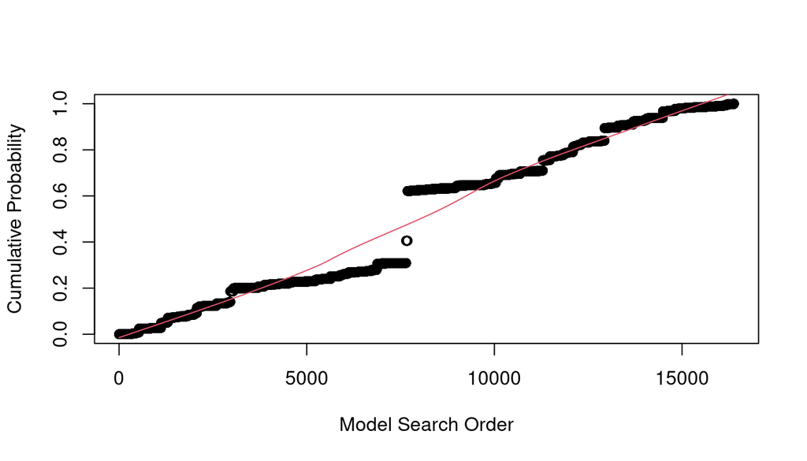

```r
plot(model.EB,caption = '', sub.caption = '',
     col.in = 'blue', col.ex = 'darkgrey', lwd = 3, ask = F, which=2 )
```

##### Dimensions

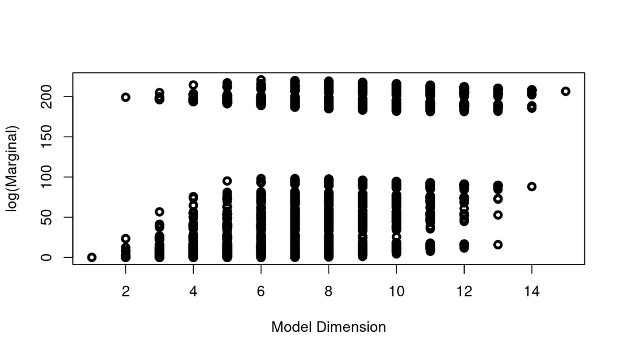

```r
plot(model.EB,caption = '', sub.caption = '',
     col.in = 'blue', col.ex = 'darkgrey', lwd = 3, ask = F, which=3 )
```

The third plot shows the dimension of each model (the number of regression coefficients including the intercept) versus the log of the marginal likelihood of the model.

##### PIP

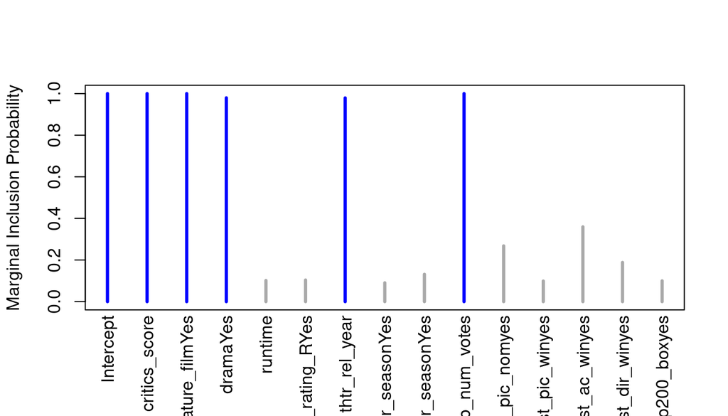

```r
plot(model.EB,caption = '', sub.caption = '',
     col.in = 'blue', col.ex = 'darkgrey', lwd = 3, ask = F, which=4 )
```

The last plot shows the marginal posterior inclusion probabilities (pip) for each of the covariates, with marginal pips greater than 0.5 shown in blue. The variables with pip > 0.5 correspond to what is known as the median probability model. Marginal inclusion probabilities may be small if there are predictors that are highly correlated, similar to how p-values may be large in the presence of multicollinearity - which is probably the case for `best_pic_nom`, `best_pic_win`, `best_ac_win`, `best_dir_win` group.

##### Residual distribution

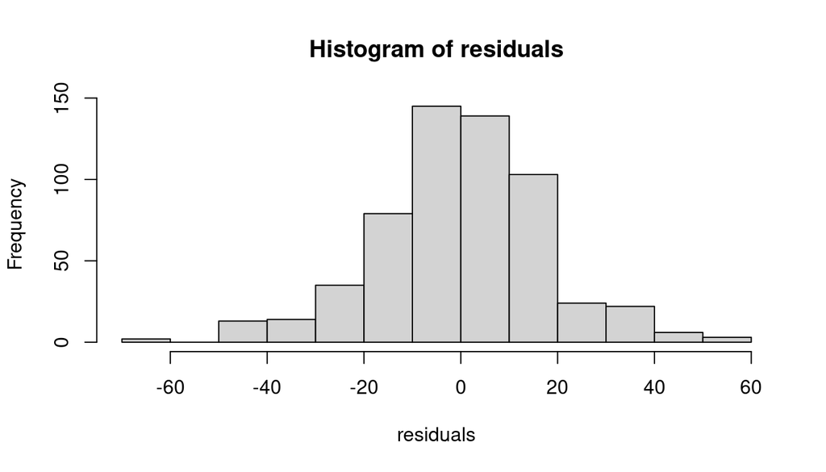

```r
residuals <- movies_short$audience_score - pred$fit

hist(residuals)
```

Distribution is fairly symmetrical and normal looking

##### QQ plot

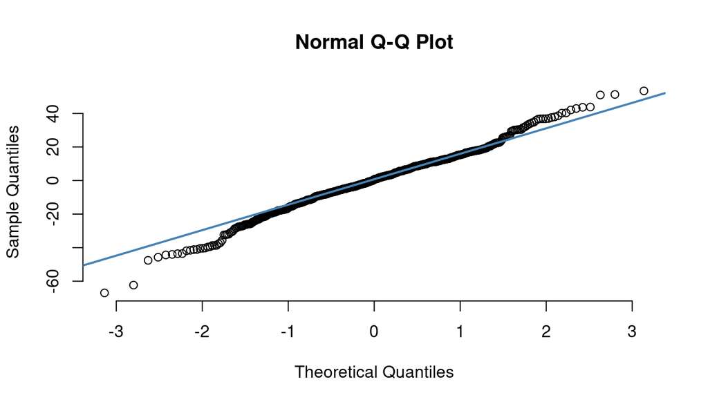

```r
qqnorm(residuals, pch = 1, frame = FALSE)
qqline(residuals, col = 'steelblue', lwd = 2)
```

QQ plot also shows that residuals distribution is close to normal

##### Residuals autocorrelation

Checking for ‘omitted variables’ which can leave traces in the residuals in the form of auto-correlation ( or inadvertent time series ).

Lag plot

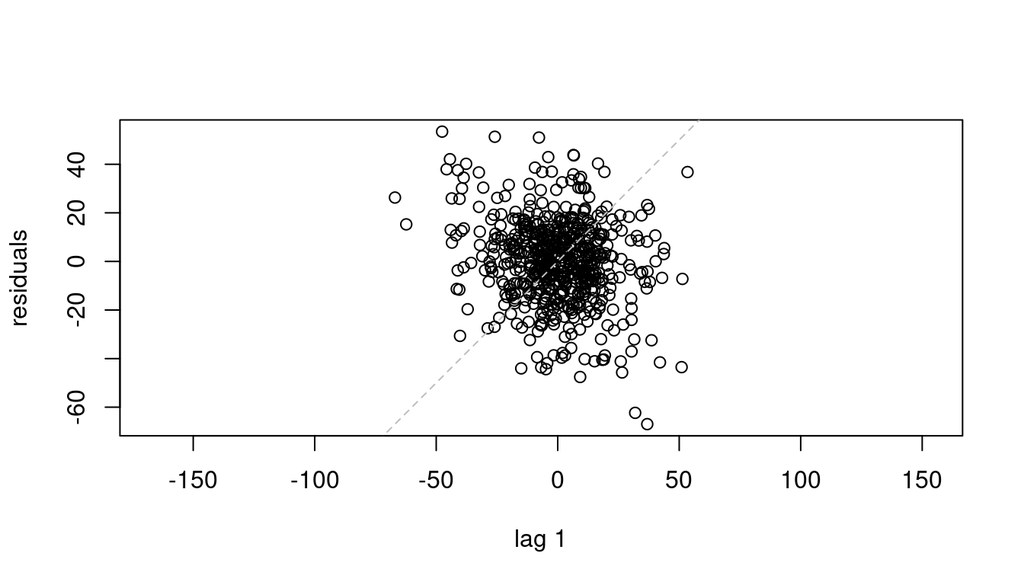

```r
lag.plot(residuals, lags = 1, do.lines = F, labels = F)
```

Looks good - no visible correlation

## Part 5: Prediction

Instead of one of the movies from 2016 I will use the test part of the data. I used movies to train models. Now I will use the remaining part to predict and compare BMA with HPM, MPM and BPM.

### BMA model

Let’s look at a few random points from test data with their CI

```r
predict.BMA <- predict(model.EB, newdata=movies_test, estimator = 'BMA', se.fit = TRUE)

out <- as.data.frame(confint(predict.BMA)[, 1:2])

# Extract the upper and lower bounds of the credible intervals
names <- c('Actual', 'Predicted', colnames(out))
out <- cbind(movies_test$audience_score, predict.BMA$fit, out)
colnames(out) <- names

picked <- sample(seq_len(nrow(out)),10)
round(out[picked,], 2)
```

```
##    Actual Predicted  2.5%  97.5%
## 51     89     91.35 64.20 117.05
## 43     35     68.08 42.02  94.90
## 41     80     76.45 49.94 104.23
## 14     88     82.05 55.84 109.44
## 9      79     77.83 51.33 104.56
## 3      60     52.81 26.31  79.63
## 44     70     70.15 42.47  95.85
## 37     89     79.78 52.61 106.04
## 54     30     39.45 13.51  66.82
## 57     51     56.63 29.46  82.27
```

We can see that the uncertainty in the prediction values is quite high and precision is not great as well.

### Other models

Lets compare all models

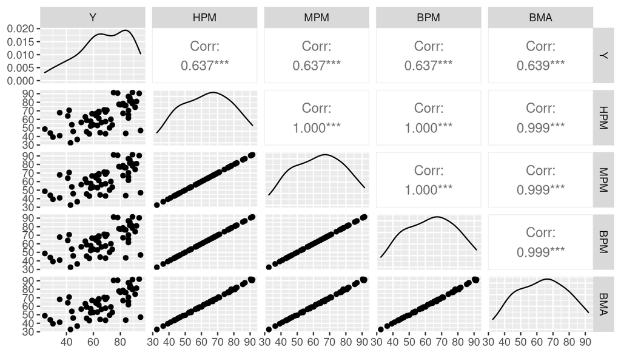

```r
predict.HPM <- predict(model.EB, newdata=movies_test, estimator = 'HPM')
predict.MPM <- predict(model.EB, newdata=movies_test, estimator = 'MPM')
predict.BPM <- predict(model.EB, newdata=movies_test, estimator = 'BPM')

ggpairs(data.frame(Y = as.vector(movies_test$audience_score),
                   HPM = as.vector(predict.HPM$fit),
                   MPM = as.vector(predict.MPM$fit),
                   BPM = as.vector(predict.BPM$fit),
                   BMA = as.vector(predict.BMA$fit)))
```

We can see that all models are identically in prediction power.

## Part 6: Conclusion

### Model explanation

Summary table

```r
out <- confint(model.EB.coefs)[, 1:2]

# Extract the upper and lower bounds of the credible intervals
names <- c('posterior mean', 'posterior std', colnames(out))
out <- cbind(model.EB.coefs$postmean, model.EB.coefs$postsd, out)
colnames(out) <- names

round(out, 2)
```

```
##                  posterior mean posterior std   2.5%  97.5%
## Intercept                 63.01          0.56  61.93  64.13
## critics_score              0.41          0.02   0.36   0.46
## feature_filmYes          -16.75          2.59 -21.90 -11.65
## dramaYes                   4.25          1.36   1.73   7.07
## runtime                    0.18          1.34  -1.26   3.86
## mpaa_rating_RYes          -0.07          0.42  -1.53   0.03
## thtr_rel_year             -0.20          0.06  -0.32  -0.08
## oscar_seasonYes           -0.01          0.39  -0.64   0.92
## summer_seasonYes          -0.15          0.59  -2.15   0.04
## imdb_num_votes             2.98          0.43   2.15   3.83
## best_pic_nomyes            1.40          2.85  -0.01   8.85
## best_pic_winyes           -0.20          1.98  -5.99   2.79
## best_ac_winyes            -0.95          1.52  -4.42   0.00
## best_dir_winyes           -0.59          1.61  -5.34   0.00
## top200_boxyes             -0.19          1.33  -4.29   0.52
```

For explanation of the movie popularity I will use variables with pip > 0.5: `critics_score`, `feature_film`, `drama`, `thtr_rel_year`, `imdb_num_votes`

### Quality of the model.

Firstly - there is not enough information in the dataset - many predictor levels have too small numbers of observations. The best possible solution is to increase a sample size. Also methods like https://www.researchgate.net/publication/257364616_SMOTE_for_Regression can be useful if collecting more data is not an option.

Another possible issue is the non-independence of observations - if you violate the assumption of independence, **you run the risk that all of your results will be wrong**, so more research is needed.

There is also a problem with heteroscedasticity and potential outliers, which requires further investigation.